# PhenolyzerR Vignette

Jonah Einson

PhenolyzerR is an R implementation of Phenolyzer, which prioritizes genes related to an input disease term. The tool leverages the tree structure of the Disease Ontology (DO) and CTD Medical ontology to extend a query term. It then uses three different knowledge bases (OMIM, ClinVar, and GWAS) to match the extended search term and generate prioritized diseaes.

To install it:

```r
install_github("jeinson/PhenolyzerR")
```

[output not shown]

[output not shown]

[output not shown]

To illustrate PhenolyzerR’s functionality, begin by extending the term “alzheimer”

```r
alzheimer_terms <- disease_extension("alzheimer")
```

```
Finished searching the Disease Ontology Database
Finished searching the CTD Medic Database
```

```r
alzheimer_terms[1:75,]
```

| Disease | Source |
| --- | --- |
| alzheimer | MY_TERM |
| Alzheimer's disease 2 | DISEASE_ONTOLOGY |
| Alzheimer's disease 16 | DISEASE_ONTOLOGY |
| Alzheimer's disease 5 | DISEASE_ONTOLOGY |
| Alzheimer's disease 6 | DISEASE_ONTOLOGY |
| Alzheimer's disease 7 | DISEASE_ONTOLOGY |
| Alzheimer's disease 4 | DISEASE_ONTOLOGY |
| Alzheimer's disease 8 | DISEASE_ONTOLOGY |
| Alzheimer's disease 3 | DISEASE_ONTOLOGY |
| Alzheimer's disease 10 | DISEASE_ONTOLOGY |

[output cut: 65 more lines]

Notice that this function automatically downloaded the CTD and DO ontology files, and placed them in your local environment. The output is conveniently in a tibble format, which is easier (or less painful) to work with than a data.frame.

Next, try outputting a prioritized gene list.

```r
output_gene_prioritization("alzheimer's disease")
```

```
Finished searching the Disease Ontology Database
Finished searching the CTD Medic Database
Disease term extension completed
Downloading ClinVar gene_condition_source_id file
Downloading GWAS gene condition associations
Fixing synonymous gene names across databases
Done!
Matching to database with extended terms!
Matching to database with input term!
```

| GeneID | GENE | reported_SCORE |
| --- | --- | --- |
| 348 | APOE | 1.00000000 |
| 10452 | TOMM40 | 0.42940822 |
| 2 | A2M | 0.39924454 |
| 10347 | ABCA7 | 0.24798817 |
| 274 | BIN1 | 0.22576227 |
| 5663 | PSEN1 | 0.21776975 |
| 3077 | HFE | 0.20567143 |
| 4353 | MPO | 0.20567143 |
| 8301 | PICALM | 0.20561663 |
| 5819 | NECTIN2 | 0.19554385 |

[output cut: 393 more lines]

Again, this function downloads the OMIM genemap, ClinVar disease-gene associations file, and GWAS gene conditions associations file. This is done by calling the `build_disease_gene_associations` function, which retrieves the tables from the web, then puts them in a convenient format. This huge gene-disease tibble is saved as `DB_COMPILED_GENE_DISEASE_SCORES`. It could be used in other applications linking diseases to genes with some level of certainty.

| GENE | DISEASE | DISEASE_ID | SCORE | SOURCE |
| --- | --- | --- | --- | --- |
| CCV | Cataract 8 multiple types | OMIM:115665 | 0.75 | OMIM |
| ENO1 | Enolase deficiency | OMIM:172430 | 1.00 | OMIM |
| HMGCL | HMGCoA lyase deficiency | OMIM:613898 | 0.75 | OMIM |
| AGRN | Myasthenic syndrome congenital 8 | OMIM:103320 | 0.75 | OMIM |
| GNB1 | Leukemia acute lymphoblastic somatic | OMIM:139380 | 1.00 | OMIM |
| GNB1 | Mental retardation autosomal dominant 42 | OMIM:139380 | 1.00 | OMIM |
| SDC3 | Obesity association | OMIM:186357 | 1.00 | OMIM |
| ATAD3A | HarelYoon syndrome | OMIM:612316 | 0.75 | OMIM |
| ISG15 | Immunodeficiency 38 | OMIM:147571 | 0.75 | OMIM |
| TMEM240 | Spinocerebellar ataxia 21 | OMIM:616101 | 1.00 | OMIM |

[output cut: 90 more lines]

To view what sourcce each gene prediction came from, pass `output_mode = "list"` in `output_gene_prioritization`

```r
BT_list_output <- output_gene_prioritization("beta thalassemia", output_mode = "list")
```

```
Splitting your query into 2 searches
Finished searching the Disease Ontology Database
Finished searching the CTD Medic Database
Finished searching the Disease Ontology Database
Finished searching the CTD Medic Database
Disease term extension completed
Matching to database with extended terms!
Matching to database with input term!
```

```r
BT_list_output[1:5]
```

```
$`KRT89P Raw score: 11.625 Normalized score: 1`
```

| GENE | DISEASE | DISEASE_ID | SCORE | SOURCE |
| --- | --- | --- | --- | --- |
| KRT89P | Thalassemias beta | OMIM:141900 | 1.0000 | OMIM |
| KRT89P | Beta-thalassemia, dominant inclusion body type | OMIM:603902 | 0.0625 | ClinVar |
| KRT89P | beta Thalassemia | OMIM:613985 | 0.0625 | ClinVar |
| KRT89P | Thalassemias beta | OMIM:141900 | 1.0000 | OMIM |
| KRT89P | Beta-thalassemia, dominant inclusion body type | OMIM:603902 | 0.0625 | ClinVar |
| KRT89P | alpha Thalassemia | OMIM:604131 | 0.0625 | ClinVar |
| KRT89P | beta Thalassemia | OMIM:613985 | 0.0625 | ClinVar |
| KRT89P | Deltabeta thalassemia | OMIM:141900 | 1.0000 | OMIM |
| KRT89P | Erythremias beta | OMIM:141900 | 1.0000 | OMIM |
| KRT89P | Heinz body anemias beta | OMIM:141900 | 1.0000 | OMIM |

[output cut: 11 more lines]

```
$`GBA Raw score: 5.25 Normalized score: 0.451612903225806`
```

| GENE | DISEASE | DISEASE_ID | SCORE | SOURCE |
| --- | --- | --- | --- | --- |
| GBA | Gaucher disease perinatal lethal | OMIM:606463 | 1.0000 | OMIM |
| GBA | Gaucher disease type I | OMIM:606463 | 1.0000 | OMIM |
| GBA | Gaucher disease type II | OMIM:606463 | 1.0000 | OMIM |
| GBA | Gaucher disease type III | OMIM:606463 | 1.0000 | OMIM |
| GBA | Gaucher disease type IIIC | OMIM:606463 | 1.0000 | OMIM |
| GBA | Gaucher's disease, type 1 | OMIM:230800 | 0.0625 | ClinVar |
| GBA | Acute neuronopathic Gaucher's disease | OMIM:230900 | 0.0625 | ClinVar |
| GBA | Subacute neuronopathic Gaucher's disease | OMIM:231000 | 0.0625 | ClinVar |
| GBA | Gaucher disease, perinatal lethal | OMIM:608013 | 0.0625 | ClinVar |

```
$`APOE Raw score: 4.87499999899238 Normalized score: 0.419354838623001`
```

| GENE | DISEASE | DISEASE_ID | SCORE | SOURCE |
| --- | --- | --- | --- | --- |
| APOE | Hyperlipoproteinemia type III | OMIM:107741 | 1.0000 | OMIM |
| APOE | Alzheimer's disease | OMIM:104300 | 0.0625 | ClinVar |
| APOE | Alzheimer disease 2 | OMIM:104310 | 0.0625 | ClinVar |
| APOE | Alzheimer's disease | PUBMED:17998437 | 0.2500 | GWAS |
| APOE | Alzheimer's disease | PUBMED:17975299 | 0.2500 | GWAS |
| APOE | Alzheimer's disease | PUBMED:18823527 | 0.2500 | GWAS |
| APOE | Alzheimer's disease | PUBMED:22245343 | 0.2500 | GWAS |
| APOE | Alzheimer's disease | PUBMED:22245343 | 0.2500 | GWAS |
| APOE | Alzheimer's disease | PUBMED:19125160 | 0.2500 | GWAS |
| APOE | Alzheimer's disease | PUBMED:19734902 | 0.2500 | GWAS |

[output cut: 8 more lines]

```
$`HBA1 Raw score: 3.125 Normalized score: 0.268817204301075`
```

| GENE | DISEASE | DISEASE_ID | SCORE | SOURCE |
| --- | --- | --- | --- | --- |
| HBA1 | alpha Thalassemia | OMIM:604131 | 0.0625 | ClinVar |
| HBA1 | Thalassemia alpha | OMIM:141850 | 1.0000 | OMIM |
| HBA1 | Thalassemias alpha | OMIM:141800 | 1.0000 | OMIM |
| HBA1 | alpha Thalassemia | OMIM:604131 | 0.0625 | ClinVar |
| HBA1 | Thalassemia alpha | OMIM:141850 | 1.0000 | OMIM |

```
$`KRT87P Raw score: 2.5 Normalized score: 0.21505376344086`
```

| GENE | DISEASE | DISEASE_ID | SCORE | SOURCE |
| --- | --- | --- | --- | --- |
| KRT87P | Beta thalassemia/hemoglobin E disease | PUBMED:20183929 | 0.25 | GWAS |
| KRT87P | Thalassemia due to Hb Lepore | OMIM:142000 | 1.00 | OMIM |
| KRT87P | Thalassemia delta | OMIM:142000 | 1.00 | OMIM |
| KRT87P | Beta thalassemia/hemoglobin E disease | PUBMED:20183929 | 0.25 | GWAS |

```
NA
```

The output of this command can be saved in a more convenient format to work with as such:

```r
cat(readLines("BT_list_output.txt")[1:50], sep = "\n")
```

```
Number of genes identified in the databases: 366
KRT89P Raw score: 11.625 Normalized score: 1
KRT89P  Thalassemias beta   OMIM:141900 1   OMIM
KRT89P  Beta-thalassemia, dominant inclusion body type  OMIM:603902 0.0625  ClinVar
KRT89P  beta Thalassemia    OMIM:613985 0.0625  ClinVar
KRT89P  Thalassemias beta   OMIM:141900 1   OMIM
KRT89P  Beta-thalassemia, dominant inclusion body type  OMIM:603902 0.0625  ClinVar
KRT89P  alpha Thalassemia   OMIM:604131 0.0625  ClinVar
KRT89P  beta Thalassemia    OMIM:613985 0.0625  ClinVar
KRT89P  Deltabeta thalassemia   OMIM:141900 1   OMIM
KRT89P  Erythremias beta    OMIM:141900 1   OMIM
KRT89P  Heinz body anemias beta OMIM:141900 1   OMIM
KRT89P  Methemoglobinemias beta OMIM:141900 1   OMIM
KRT89P  Thalassemiabeta dominant inclusionbody  OMIM:141900 1   OMIM
KRT89P  Thalassemias beta   OMIM:141900 1   OMIM
KRT89P  Beta-thalassemia, dominant inclusion body type  OMIM:603902 0.0625  ClinVar
KRT89P  beta Thalassemia    OMIM:613985 0.0625  ClinVar
KRT89P  Deltabeta thalassemia   OMIM:141900 1   OMIM
KRT89P  Thalassemiabeta dominant inclusionbody  OMIM:141900 1   OMIM
KRT89P  Thalassemias beta   OMIM:141900 1   OMIM
KRT89P  Beta-thalassemia, dominant inclusion body type  OMIM:603902 0.0625  ClinVar
KRT89P  alpha Thalassemia   OMIM:604131 0.0625  ClinVar
KRT89P  beta Thalassemia    OMIM:613985 0.0625  ClinVar

GBA Raw score: 5.25 Normalized score: 0.451612903225806
GBA Gaucher disease perinatal lethal    OMIM:606463 1   OMIM
GBA Gaucher disease type I  OMIM:606463 1   OMIM
GBA Gaucher disease type II OMIM:606463 1   OMIM
GBA Gaucher disease type III    OMIM:606463 1   OMIM
GBA Gaucher disease type IIIC   OMIM:606463 1   OMIM
GBA Gaucher's disease, type 1   OMIM:230800 0.0625  ClinVar
GBA Acute neuronopathic Gaucher's disease   OMIM:230900 0.0625  ClinVar
GBA Subacute neuronopathic Gaucher's disease    OMIM:231000 0.0625  ClinVar
GBA Gaucher disease, perinatal lethal   OMIM:608013 0.0625  ClinVar

APOE Raw score: 4.87499999899238 Normalized score: 0.419354838623001
APOE    Hyperlipoproteinemia type III   OMIM:107741 1   OMIM
APOE    Alzheimer's disease OMIM:104300 0.0625  ClinVar
APOE    Alzheimer disease 2 OMIM:104310 0.0625  ClinVar
APOE    Alzheimer's disease PUBMED:17998437 0.25    GWAS
APOE    Alzheimer's disease PUBMED:17975299 0.25    GWAS
APOE    Alzheimer's disease PUBMED:18823527 0.249999999999985   GWAS
APOE    Alzheimer's disease PUBMED:22245343 0.24999999999999983 GWAS
APOE    Alzheimer's disease PUBMED:22245343 0.249999999 GWAS
APOE    Alzheimer's disease PUBMED:19125160 0.25    GWAS
APOE    Alzheimer's disease PUBMED:19734902 0.25    GWAS
APOE    Alzheimer's disease PUBMED:20061627 0.2499999999925 GWAS
APOE    Alzheimer's disease PUBMED:19734903 0.24999999999999994 GWAS
APOE    Alzheimer's disease PUBMED:21627779 0.25    GWAS
APOE    Alzheimer's disease PUBMED:22832961 0.25    GWAS
```

For this example, it may be better to not split the disease name into two search queries, because “beta” and “thalassemia” might match different terms than we actually want. For this purpose, pass `split = FALSE` in the function call.

```r
cat(readLines("BT_no_split_list_output.txt"), sep = "\n")
```

[output not shown]

This increases the probability of identifying a correct gene, but decreases PhenolyzerR’s power to find more distantly related genes to the query term.

Finally, the prioritized gene list can be visualized with a wordcloud. This feature is baked into the `output_gene_prioritization` function. It is used as such:

```
Splitting your query into 2 searches
Finished searching the Disease Ontology Database
Finished searching the CTD Medic Database
Finished searching the Disease Ontology Database
Finished searching the CTD Medic Database
Disease term extension completed
Matching to database with extended terms!
Matching to database with input term!
```

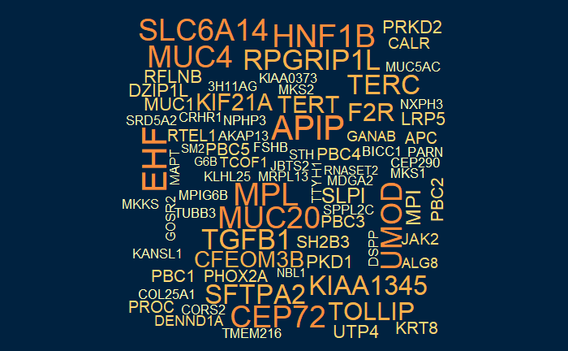

```r
output_gene_prioritization("cystic fibrosis", wordcloud = TRUE, return_output = FALSE)
```

```
Term splitting will not be performed
Finished searching the Disease Ontology Database
Finished searching the CTD Medic Database
Disease term extension completed
Matching to database with extended terms!
Matching to database with input term!
```

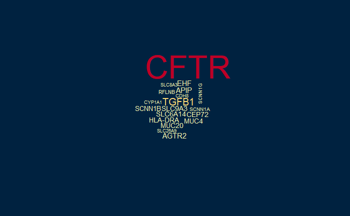

```r
output_gene_prioritization("cystic fibrosis", split = FALSE, wordcloud = TRUE, return_output = FALSE)
```